# MET_Operational

Modified

June 3, 2025

## 1. MET Landing page

The figure below shows a potential landing page for the Model Evaluation Tool (MET).

[figure not shown]

## 2. Evaluators and other users landing page

This page will allow users the evaluation status of all species within a project of interest. Users can select species and visualize detailed information about model materials (inputs, outputs and metadata), feedback received fro evaluators, actions proposed, modelers’ adjustments and improvements.

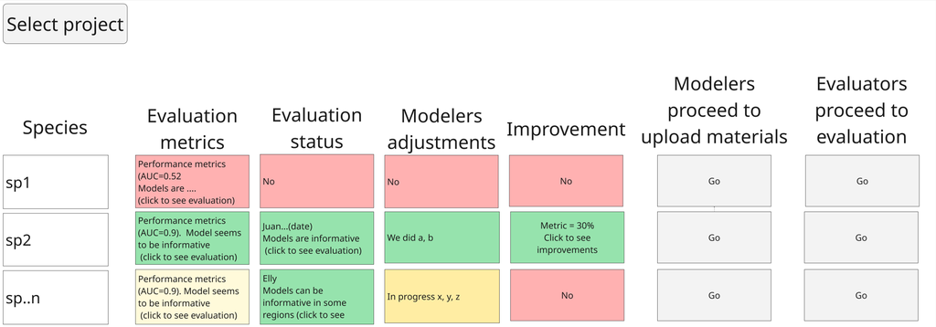

## 3. Modelers landing page after selecting species of interest

Modelers will use the customized ODMAP (developed by Zurrell Lab) to upload model metadata.

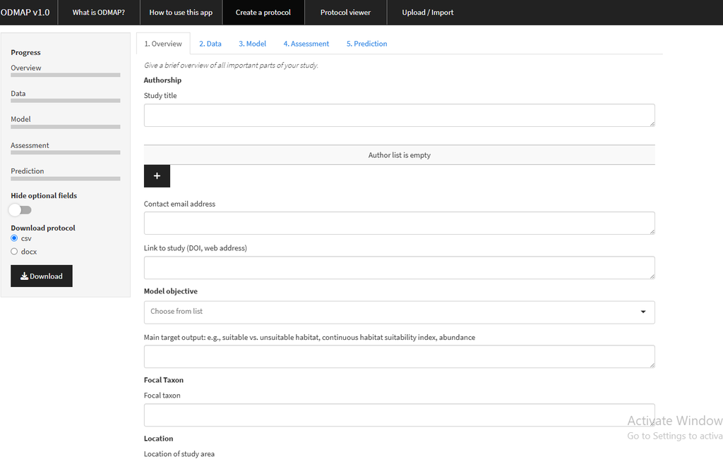

## 4. Evaluators landing page after selecting species of interest

These pages merge the materials (inputs, outputs and metadata) from the modeler and the questions evaluators will respond to provide feedback.

The first page is the landing page containing tab1: evaluators information, tab2: model predictions and uncertainty, as well as, general information about the model, tab3 evaluators can create their own path to explore in detail and provide feedback on other model materials.

Note that purple boxes are places where we expect evaluators feedback.

Yellow boxes are information coming from the metadata.

**Evaluator**

[figure not shown]

**Predictions & uncertainty**

[figure not shown]

**My path**

Then, evaluators can define their own path(s) of evaluation within the model cycle.

Users will have the opportunity to review and analyse information about the model, provide feedback and extract strategic information according to their purpose of evaluation.

[figure not shown]

**Evaluation**

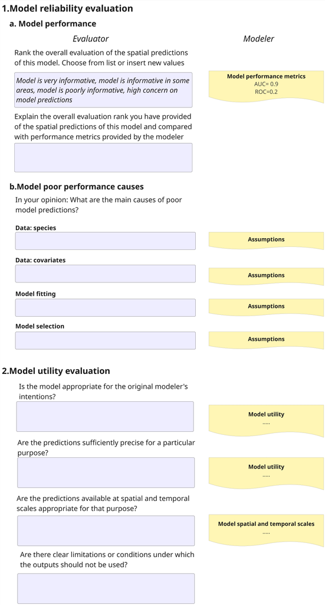

**Actions**

[figure not shown]